# Assignment 2

Ebru Gecici

16/08/2020

This report includes implementation of the **dplyr()** function and **ggplot()** function by using EPIAS 01-31 July 2020 data. To make analysis, first the data is rearranged to analyze and then required calculations are made to get meaningful outputs. By using this outputs, interpretation can be made for July 2020.

More detailed from different time frame can be found in the [EPIAS](https://rapor.epias.com.tr/rapor/xhtml/ptfSmfListeleme.xhtml).

## IMPLEMENTATION OF THE `dplyr()` and `ggplot()`

## EPIAS ELECTRICTY REPORT

Electricity market provide transparency, competition and integration with other electricity markets. Main purpose of this system is to provide stronger achievement in the dynamic system [(1)](https://www.epias.com.tr/en/day-ahead-market/introduction/). For this reason, to provide more information and obtain better prediction about the future energy market, there are available data sets. By analyzing this data, balanced energy market can be achieved. The balanced electricity market means that the produced and consumed energy are in the same level. That is, you produce electricity that you needs. As the price of the electricity in huge amounts, especially in this technology era, this is more important.

To start basic implementation about the electricity price, this report is prepared. In this report, *July 2020* data is used.This data consists of six different values:

1. date,
2. market clearing price,
3. system marginal price,
4. positive imbalance price,
5. negative imbalance price,
6. system marginal price direction.

The **date** is the date information, i.e., day, month, year and the hour, minute, second information. The **market clearing price** is obtain when the produced/supplied is equal to consumed price. This price is also called *equilibrium price*. **System marginal price**, on the other hand, is used in the imbalance/ in-equilibrium point. If there is energy deficit in system, the lowest price for electricity is offered, whereas, if there is energy surplus in the system the highest price is offered. By using these classification, deficit and surplus, the system marginal price direction is defined [(2)](https://www.epias.com.tr/en/balancing-market/system-marginal-price-smp/#:~:text=System%20marginal%20price%20is%20calculated,energy%20surplus%20in%20the%20system.). When the energy demand is more than the predicted demand, **deficit** is occurred in the system. In contrast to deficit, when the energy demand is lower than the predicted demand, **surplus** is observed. If market clearing price is greater than the system marginal price, the energy surplus is obtained, otherwise we get energy deficit in the system. Moreover, by using market clearing price and system marginal price, we obtain positive **imbalance price** and **negative imbalance price**:

- Positive Imbalance Price = min(MCP,SMP)*0.97
- Negative Imbalance Price = max(MCP,SMP)*1.03

These calculations show that market operator penalize the system [(3)](https://boun-ie48a.github.io/files/electricity_markets_mini_tutorial) and this process is called imbalance price.

### 1. DATA MANUPILATION

#### 1.1. Data

To make analysis, we first load the packages and manipulate the data to obtain clearer results. For this, after the loading of the data, we check the data type for the calculations.

```r
#we call required packages from the packages which are "tidyverse" and "lubridate"
library(tidyverse)
library(lubridate)
library(ggplot2)
#we upload data, which is csv file format, by using read.csv() function
EpiasData <- read.csv("ptf-smf.csv")
#after the control of the data we can examine columns in the data by using glimpse() function
EpiasData %>%
  glimpse()
```

```
## Rows: 744
## Columns: 6
## $ Date                              <chr> "01.07.20 00:00", "01.07.20 01:00...
## $ MCP.                              <dbl> 323.85, 326.95, 324.31, 322.11, 3...
## $ SMP.                              <dbl> 211.00, 201.00, 211.00, 211.00, 2...
## $ Positive.Imbalance.Price..TL.MWh. <dbl> 204.67, 194.97, 204.67, 204.67, 1...
## $ Negative.Imbalance.Price..TL.MWh. <dbl> 333.57, 336.76, 334.04, 331.77, 3...
## $ SMP.Direction                     <chr> "?Energy Surplus", "?Energy Surpl...
```

```r
#then we control our date type because in the functions we need date type
is.Date(EpiasData$Date)
```

```
## [1] FALSE
```

```r
#as the date column is not date type, first we convert "." to "-" by using gsub() function
EpiasData$Date <- gsub(pattern = "\\.","-",EpiasData$Date)
#after the changing we transform our date time from character to dttm by using a function of lubridate which is as.POSIXct
EpiasData$Date <- as.POSIXct(EpiasData$Date,format="%d-%m-%y %H:%M")
#control of the process
EpiasData %>%
  glimpse()
```

```
## Rows: 744
## Columns: 6
## $ Date                              <dttm> 2020-07-01 00:00:00, 2020-07-01 ...
## $ MCP.                              <dbl> 323.85, 326.95, 324.31, 322.11, 3...
## $ SMP.                              <dbl> 211.00, 201.00, 211.00, 211.00, 2...
## $ Positive.Imbalance.Price..TL.MWh. <dbl> 204.67, 194.97, 204.67, 204.67, 1...
## $ Negative.Imbalance.Price..TL.MWh. <dbl> 333.57, 336.76, 334.04, 331.77, 3...
## $ SMP.Direction                     <chr> "?Energy Surplus", "?Energy Surpl...
```

#### 1.2. Rename columns and rearrange the data frame

To provide more understandable data, I change the name of the column. This process is provide the uses to get clear information about data.

```r
#then, I changed the name of the column by using transmute() function with pipe operator. And then I assigned this process into
# raw_df name as a data frame. After this process, we have usable data frame
raw_df <- EpiasData %>%
  transmute(Date,
            #rename of the MCP. column
            MCP = MCP.,
            SMP = SMP.,
            PositiveIP = Positive.Imbalance.Price..TL.MWh.,
            NegativeIP = Negative.Imbalance.Price..TL.MWh.,
            SMPDirection = SMP.Direction)

#showing first sith raw of the data frame
head(raw_df)
```

```
##                  Date    MCP SMP PositiveIP NegativeIP    SMPDirection
## 1 2020-07-01 00:00:00 323.85 211     204.67     333.57 ?Energy Surplus
## 2 2020-07-01 01:00:00 326.95 201     194.97     336.76 ?Energy Surplus
## 3 2020-07-01 02:00:00 324.31 211     204.67     334.04 ?Energy Surplus
## 4 2020-07-01 03:00:00 322.11 211     204.67     331.77 ?Energy Surplus
## 5 2020-07-01 04:00:00 320.00 201     194.97     329.60 ?Energy Surplus
## 6 2020-07-01 05:00:00 286.21 181     175.57     294.80 ?Energy Surplus
```

The output shows that, Our data frame is ready for the calculations. That is, the class of the date is changed from character to date-time (dttm). By using this type, we can use *lubridate()* function to calculate, group, etc. After the data manipulation, we start to analyze. The rest of the report is arranged as follow. In the first part of the analysis section, MCP is given. Then the SMP and its relation with the MCP is taken into account. After that, the imbalance price analyzed. Finally, the SMP direction is investigated.

### 2. ANALYSIS

In the analysis of clear data,

- First, I give the visualized outputs to make interpretation,
- Then, I give the calculated outputs

In both, dplyr() function is to prepare and manipulate the data frame for visualization and mathematical analyses. Basic Information About Data (note that the more information about this values are explaned in the previous section):

- **MCP**: Market Clearing Price
- **SMP**: System Marginal Price
- **PositiveIP**: Positive Imbalance Price
- **NegativeIP**: Negative Imbalace Price
- **SMPDirection**: Sytem Marginal Price Direction

#### 2.1. MCP

#### 2.1.1. Hourly MCP

By using minimum and maximum value of the hourly MCP by using following function.

```r
raw_df %>%
        select(Date, MCP)%>%
        #first we group our data according to the hours
        group_by(Hour = lubridate::hour(Date))%>%
        #then we calculate average value of MCP hour each our
        summarise(MinMCP_Hour = min(MCP),
                  MaxMCP_Hour = max(MCP))%>%
        #ungproup
        ungroup()%>%
        #to provide sorting of the data hourly minimum MCP and hourly maximum MCP from smallest to largest
        arrange(MinMCP_Hour,MaxMCP_Hour)%>%
        print(n=3)
```

```
## # A tibble: 24 x 3
##    Hour MinMCP_Hour MaxMCP_Hour
##   <int>       <dbl>       <dbl>
## 1     6        140.        293
## 2     9        174.        328.
## 3     7        194.        318.
## # ... with 21 more rows
```

#### 2.1.2. Graph of the öinimum and maximum values of the MCP according to the hours

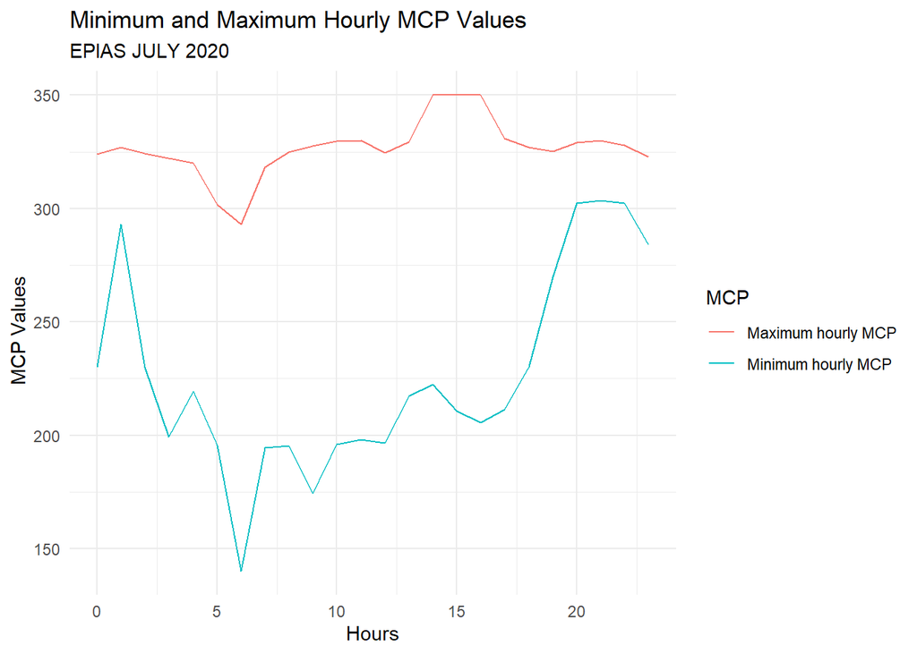

```r
raw_df%>%
  #group according to the hours
  group_by(Hours=lubridate::hour(Date))%>%
  #finding minimum and maximum value of the MCP
  summarise(MinMCP_Hour = min(MCP),
            MaxMCP_Hour = max(MCP))%>%
  #to visualize these min and max values by using ggplot() function according to the hours
  ggplot(aes(x=Hours)) +
    #define lines in the graph
    geom_line(aes(y = MinMCP_Hour, color = "Minimum hourly MCP"))+
    geom_line(aes(y = MaxMCP_Hour, color = "Maximum hourly MCP"))+
    #give a name to the graph
    labs( title = "Minimum and Maximum Hourly MCP Values",
          subtitle = "EPIAS JULY 2020",
          color = "MCP",
          x = "Hours",
          y = " MCP Values")+
    #type of the graph, these function provide white canvas
    theme_minimal()
```

After the this calculations for each hour, we can also obtain hourly average MCP values and we can illustrates in the graph like as follow. While the minimum value of the MCP is observed in the sixth hour, the average is minimum in this hour. This is fact. Moreover, if the minimum value is too close to maximum MCP value, we can obtain higher average value of MCP in the hourly results.

#### 2.1.3. Graph of the hourly average MCP value

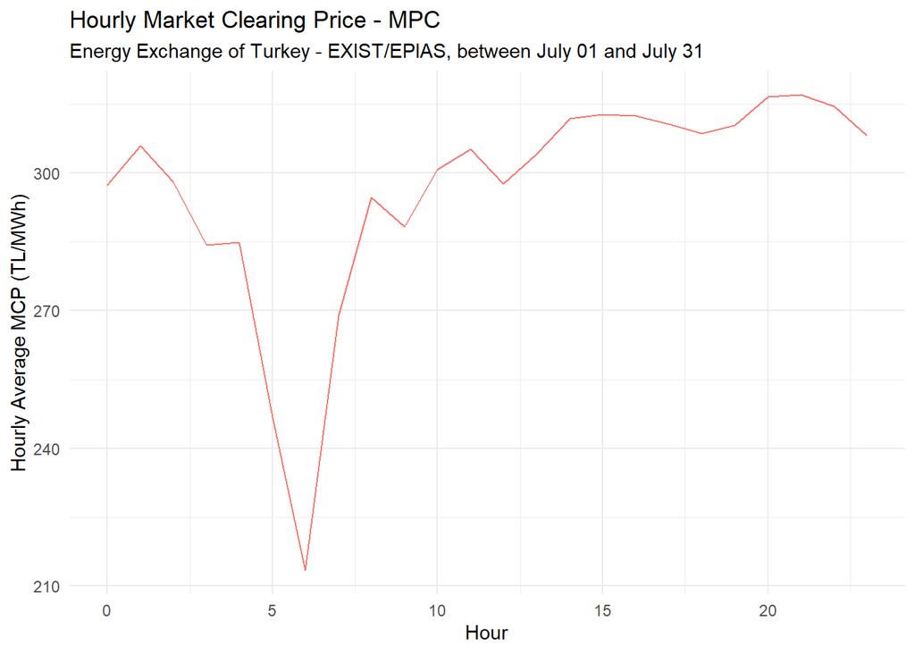

```r
#After all this process by using raw_df data frame, we can make analysis about the EPIAS data which is related to electricity
#Daily average MCP
plot1<-raw_df %>%
        #first we group our data according to the hours
        group_by(Hours = lubridate::hour(Date))%>%
        #then we calculate average value of MCP hour each our
        summarise(#daily_total_MCP = sum(MCP),
                  hourly_average_MCP = mean(MCP))
#to visualize the result we use ggplot() function, which gives the canvas of the graph
ggplot(plot1, aes(x = Hours)) +
  #geom_line() gives the line graph
  geom_line(aes(y= hourly_average_MCP, color="Hourly average MCP")) +
  labs(x = "Hour", y = "Hourly Average MCP (TL/MWh)",
       title = "Hourly Market Clearing Price - MPC",
       subtitle = "Energy Exchange of Turkey - EXIST/EPIAS, between July 01 and July 31 ")+
  theme_minimal() +
  theme(legend.position = "none")
```

In addition to the hourly analysis of the MCP, we can also make these calculations for each day. For this purpose, first we define minimum and maximum value of each day, and then we calculate average value of the daily MCP value. Finally, by using visualization tools, the outputs can be analyzed.

#### 2.1.4. Weekly MCP

- WA_MCP : Weekly Average MCP value

```r
EG <- raw_df %>%
        group_by(Week=lubridate::week(Date))%>%
        summarise(WA_MCP = mean(MCP),
                  MinMCP = min(MCP),
                  MaxMCP = max(MCP))

knitr::kable(EG, format="markdown")
```

| Week | WA_MCP | MinMCP | MaxMCP |
| --- | --- | --- | --- |
| 27 | 299.3835 | 164.64 | 349.99 |
| 28 | 282.5803 | 140.01 | 321.35 |
| 29 | 300.1358 | 194.65 | 334.99 |
| 30 | 304.2971 | 193.26 | 350.00 |
| 31 | 294.1286 | 196.09 | 349.99 |

#### 2.1.5. Graph of weekly MCP

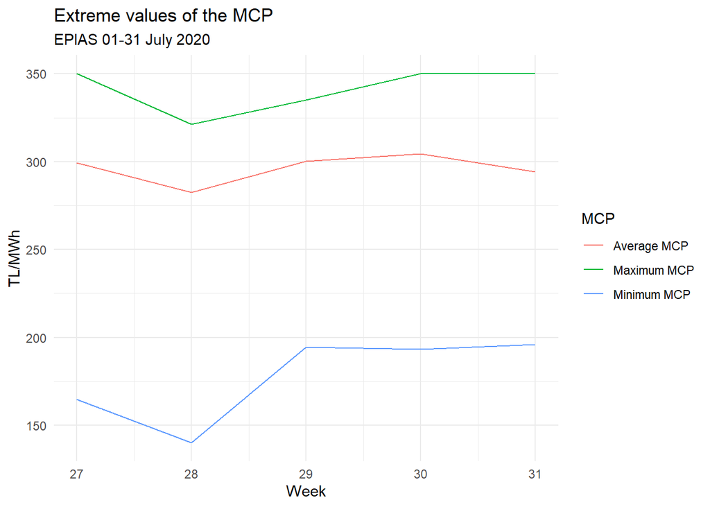

```r
#Minimum and maximum value of the MCP according to the day
raw_df %>%
  group_by(Week=lubridate::week(Date))%>%
  summarise(MinMCP = min(MCP), MaxMCP = max(MCP), Average = mean(MCP))%>%
  ggplot(aes(x=Week)) +
    geom_line(aes(y = MinMCP, color = "Minimum MCP")) +
    geom_line(aes(y = MaxMCP, color = "Maximum MCP")) +
    geom_line(aes(y = Average, color = "Average MCP")) +
    labs(x = "Week",
         y = "TL/MWh",
         title = "Extreme values of the MCP",
         subtitle = "EPIAS 01-31 July 2020",
         color = "MCP") +
    theme_minimal()
```

#### 2.1.6. Daily MCP

- DA_MCP : Daily Average MCP value

```r
raw_df %>%
  group_by(Day=lubridate::day(Date))%>%
  summarise(DA_MCP = mean(MCP))
```

```
## # A tibble: 31 x 2
##      Day DA_MCP
##    <int>  <dbl>
##  1     1   320.
##  2     2   298.
##  3     3   317.
##  4     4   306.
##  5     5   258.
##  6     6   290.
##  7     7   307.
##  8     8   304.
##  9     9   288.
## 10    10   282.
## # ... with 21 more rows
```

#### 2.1.7. Graph of daily MCP

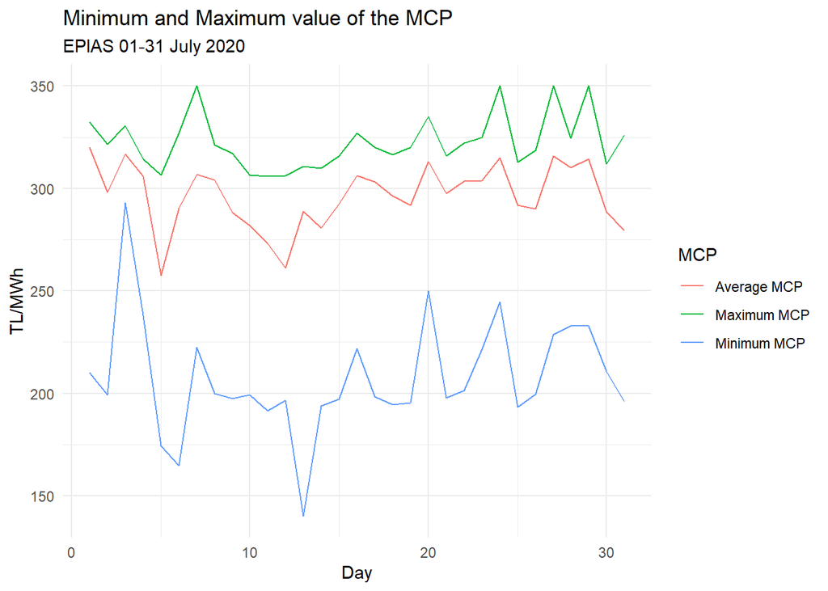

```r
#Minimum and maximum value of the MCP according to the day
raw_df %>%
  group_by(Day=lubridate::day(Date))%>%
  summarise(MinMCP = min(MCP), MaxMCP = max(MCP), Average = mean(MCP))%>%
  ggplot(aes(x=Day)) +
    geom_line(aes(y = MinMCP, color = "Minimum MCP")) +
    geom_line(aes(y = MaxMCP, color = "Maximum MCP")) +
    geom_line(aes(y = Average, color = "Average MCP")) +
    labs(x = "Day",
         y = "TL/MWh",
         title = "Minimum and Maximum value of the MCP",
         subtitle = "EPIAS 01-31 July 2020",
         color = "MCP") +
    theme_minimal()
```

```r
EG <- raw_df %>%
        select(Date, MCP)%>%
        group_by(Day = lubridate::day(Date))%>%
        summarise(DailyMCP = sum(MCP)) %>%
        ungroup()%>%
        mutate(DailyMCPNext=lag(DailyMCP,1))%>%
        transmute(Day, DailyMCP,DailyMCPNext, percentage=((DailyMCPNext-DailyMCP)/DailyMCP)-1)%>%
        arrange(desc(percentage))

#knitr::kable(EG, format="markdown")
```

#### 2.2. SMP

```r
raw_df%>%
  group_by(Day=lubridate::day(Date))%>%
  summarise(Average_SMP = mean(SMP),
            Min_SMP = min(SMP),
            Max_SMP = max(SMP))
```

```
## # A tibble: 31 x 4
##      Day Average_SMP Min_SMP Max_SMP
##    <int>       <dbl>   <dbl>   <dbl>
##  1     1        268.    114.    377.
##  2     2        357.    229.    404.
##  3     3        373.    335.    460
##  4     4        321.    235     365
##  5     5        198.    120     266.
##  6     6        307.    156.    367.
##  7     7        298.    179     353.
##  8     8        191.    151.    235.
##  9     9        189.    124.    207.
## 10    10        292.    177.    344.
## # ... with 21 more rows
```

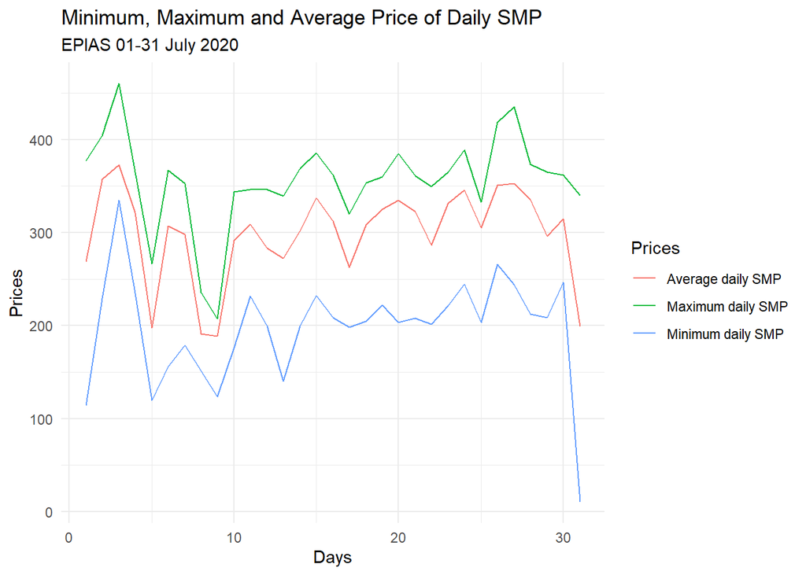

```r
raw_df%>%
  group_by(Day=lubridate::day(Date))%>%
  summarise(Average_SMP = mean(SMP),
            Min_SMP = min(SMP),
            Max_SMP = max(SMP)) %>%

  ggplot(aes(x=Day, color = "Days"))+
    geom_line(aes(y = Average_SMP, color = "Average daily SMP")) +
    geom_line(aes(y = Min_SMP, color = "Minimum daily SMP")) +
    geom_line(aes(y = Max_SMP, color = "Maximum daily SMP")) +
    theme_minimal() +
    labs(title = "Minimum, Maximum and Average Price of Daily SMP",
         subtitle = "EPIAS 01-31 July 2020",
         x= "Days",
         y= "Prices",
         color = "Prices")
```

#### 2.2.3 Weekly change of the SMP

```r
EG<- raw_df%>%
      group_by(Week=lubridate::week(Date))%>%
      summarise(Average_SMP = mean(SMP),
                Min_SMP = min(SMP),
                Max_SMP = max(SMP))
#this line provide table format in the R markdown page
knitr::kable(EG, format="markdown")
```

| Week | Average_SMP | Min_SMP | Max_SMP |
| --- | --- | --- | --- |
| 27 | 303.1767 | 113.75 | 460.00 |
| 28 | 262.5493 | 123.75 | 368.78 |
| 29 | 314.6715 | 198.55 | 385.76 |
| 30 | 329.6039 | 201.18 | 435.00 |
| 31 | 269.8582 | 10.00 | 365.00 |

#### 2.2.4 Graph of weekly change of the SMP

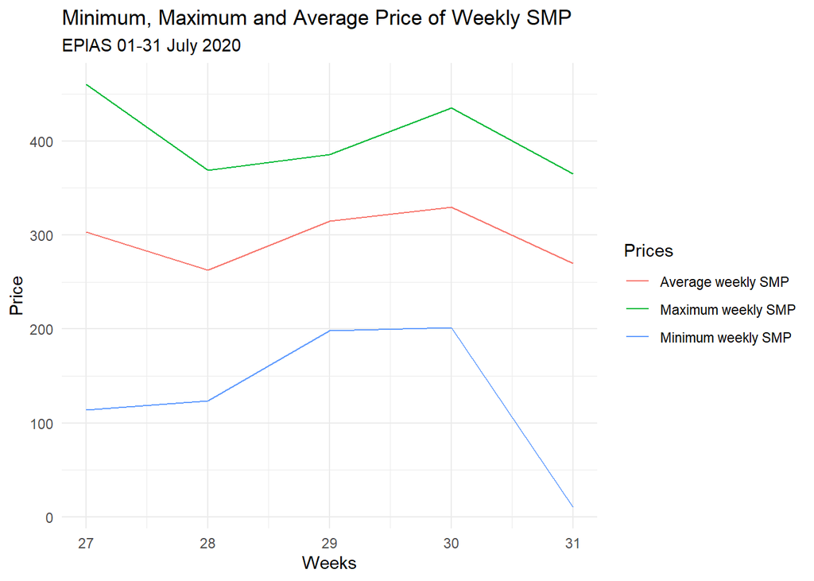

```r
raw_df%>%
  group_by(Week=lubridate::week(Date))%>%
  summarise(Average_SMP = mean(SMP),
            Min_SMP = min(SMP),
            Max_SMP = max(SMP)) %>%

  ggplot(aes(x=Week, color = "Days"))+
    geom_line(aes(y = Average_SMP, color = "Average weekly SMP")) +
    geom_line(aes(y = Min_SMP, color = "Minimum weekly SMP")) +
    geom_line(aes(y = Max_SMP, color = "Maximum weekly SMP")) +
    theme_minimal() +
    labs(title = "Minimum, Maximum and Average Price of Weekly SMP",
         subtitle = "EPIAS 01-31 July 2020",
         x="Weeks",
         y="Price",
         color = "Prices")
```

#### 2.3. Relationship Between MCP and SMP

#### 2.3.1. MCP and SMP

We can obtain daily average value of the MCP and SMP by using following lines:

```r
#average value of the MCP in weeks
EG <- raw_df %>%
        group_by(Day = lubridate::day(Date))%>%
        summarise(Average_MCP = mean(MCP),
                  Average_SMP = mean(SMP),
                  Difference = abs(mean(MCP) - mean(SMP))) %>%
        ungroup()%>%
        arrange(desc(Difference))

knitr::kable(EG, format="markdown")
```

| Day | Average_MCP | Average_SMP | Difference |
| --- | --- | --- | --- |
| 8 | 304.0046 | 190.8692 | 113.13542 |
| 9 | 288.2375 | 188.8638 | 99.37375 |
| 31 | 279.5725 | 198.7842 | 80.78833 |
| 26 | 289.9171 | 350.4929 | 60.57583 |
| 5 | 257.5275 | 197.7721 | 59.75542 |
| 2 | 298.2683 | 356.9079 | 58.63958 |
| 3 | 316.6133 | 372.7733 | 56.16000 |
| 1 | 320.1354 | 268.3675 | 51.76792 |
| 15 | 292.4921 | 337.4846 | 44.99250 |
| 17 | 303.2704 | 262.7879 | 40.48250 |
| 27 | 315.8171 | 352.7588 | 36.94167 |
| 11 | 273.2638 | 309.0046 | 35.74083 |
| 19 | 291.8637 | 324.9617 | 33.09792 |
| 24 | 314.9321 | 345.9442 | 31.01208 |
| 23 | 303.9325 | 331.4333 | 27.50083 |
| 30 | 288.3767 | 315.0079 | 26.63125 |
| 28 | 310.1596 | 335.2754 | 25.11583 |
| 21 | 297.4667 | 322.5717 | 25.10500 |
| 12 | 261.0908 | 283.1854 | 22.09458 |
| 20 | 313.2696 | 334.8942 | 21.62458 |
| 14 | 280.7529 | 301.7425 | 20.98958 |
| 29 | 314.4367 | 295.7825 | 18.65417 |
| 22 | 303.5113 | 286.3546 | 17.15667 |
| 6 | 290.1829 | 306.9533 | 16.77042 |
| 13 | 288.8896 | 272.3062 | 16.58333 |
| 4 | 306.0008 | 321.3442 | 15.34333 |
| 25 | 291.8100 | 304.9679 | 13.15792 |
| 18 | 296.2083 | 308.0858 | 11.87750 |
| 10 | 281.8229 | 291.8733 | 10.05042 |
| 7 | 306.9558 | 298.1183 | 8.83750 |
| 16 | 306.3796 | 311.9146 | 5.53500 |

#### 2.3.2. Graph of the relationship between MCP and SMP

Graph of the daily average value of MCP and SCP with line graph

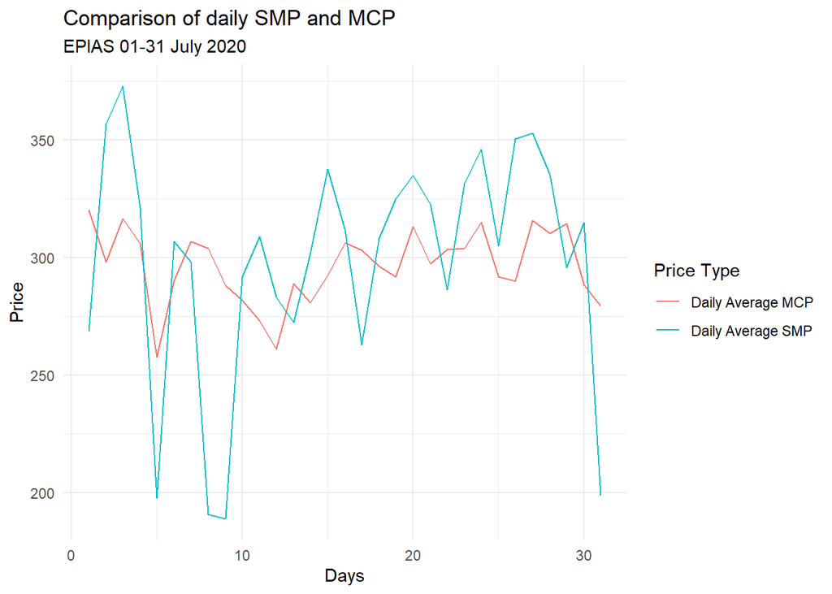

```r
#average value of the MCP in weeks
raw_df %>%
  group_by(Day = lubridate::day(Date))%>%
  summarise(Daily_MCP = mean(MCP),
            Daily_SMP = mean(SMP)) %>%

  ggplot(aes(x = Day)) +
    geom_line(aes(y = Daily_MCP, color = "Daily Average MCP")) +
    geom_line(aes(y = Daily_SMP, color = "Daily Average SMP")) +
    theme_minimal() +
    labs(title = "Comparison of daily SMP and MCP",
         subtitle = "EPIAS 01-31 July 2020",
         x="Days",
         y="Price",
         color="Price Type")
```

#### 2.3.3. The weekly relationship between MCP and SMP

We can obtain weekly average value of the MCP and SMP by using following lines:

```r
#average value of the MCP in weeks
raw_df %>%
  group_by(Week = lubridate::week(Date))%>%
  summarise(Weekly_MCP = mean(MCP),
            Weekly_SMP = mean(SMP),
            Difference = abs(mean(MCP) - mean(SMP))) %>%
  ungroup()%>%
  arrange(desc(Difference))
```

```
## # A tibble: 5 x 4
##    Week Weekly_MCP Weekly_SMP Difference
##   <dbl>      <dbl>      <dbl>      <dbl>
## 1    30       304.       330.      25.3
## 2    31       294.       270.      24.3
## 3    28       283.       263.      20.0
## 4    29       300.       315.      14.5
## 5    27       299.       303.       3.79
```

#### 2.3.4. Graph of the weekly relationship between MCP and SMP

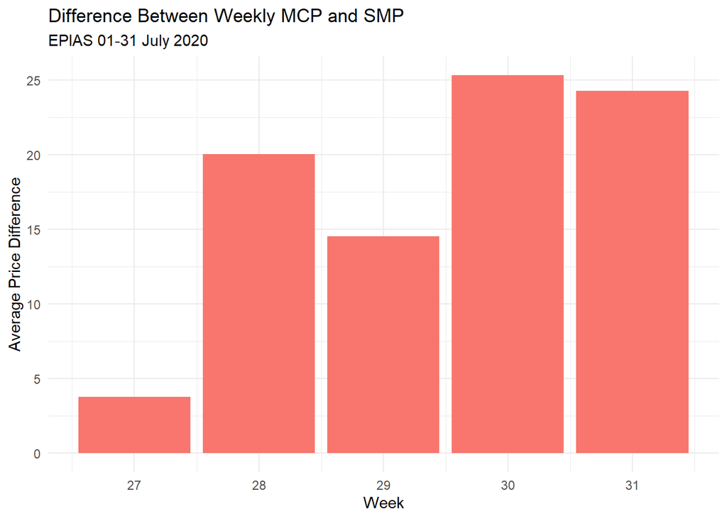

```r
#average value of the MCP in weeks
raw_df %>%
  group_by(Week = lubridate::week(Date))%>%
  summarise(Weekly_MCP = mean(MCP),
            Weekly_SMP = mean(SMP),
            Difference = abs(mean(MCP) - mean(SMP))) %>%

  ggplot(aes(x = Week, y = Difference, fill = "Weeks")) +
    geom_bar(stat = "identity") +
    theme_minimal()+
    theme(legend.position = "none") +
    labs(title = "Difference Between Weekly MCP and SMP ",
         subtitle = "EPIAS 01-31 July 2020",
         x = "Week",
         y = "Average Price Difference")
```

#### 2.3.5. Graph of the daily relationship between MCP and SMP

After the calculation of the weekly average, we can visualize the daily average of MCP and SMP values by following.

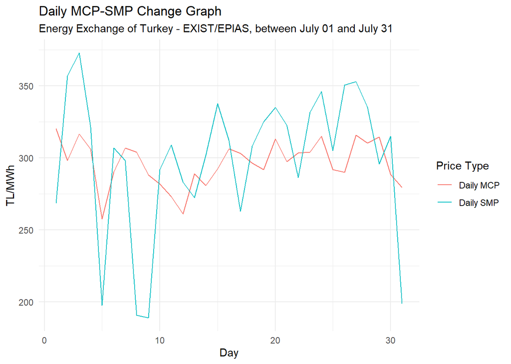

```r
#Daily change of average change MCP-SMP
raw_df %>%
  group_by(Time=lubridate::day(Date))%>%
  summarise(Daily_MCP = mean(MCP), Daily_SMP = mean(SMP)) %>%
  ggplot(aes(x=Time)) +
    geom_line(aes(y=Daily_MCP, color = "Daily MCP")) +
    geom_line(aes(y=Daily_SMP, color = "Daily SMP")) +
    labs(x = "Day", y = "TL/MWh",
       title = "Daily MCP-SMP Change Graph",
       subtitle = "Energy Exchange of Turkey - EXIST/EPIAS, between July 01 and July 31 ",
       color = "Price Type")+
  theme_minimal()
```

#### 2.3.6. Graph of the daily relationship between MCP and SMP

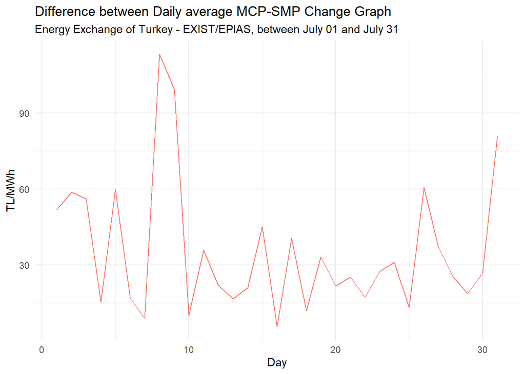

```r
#Daily change of average change MCP-SMP
raw_df %>%
  group_by(Time=lubridate::day(Date))%>%
  summarise(Daily_MCP = mean(MCP),
            Daily_SMP = mean(SMP),
            Difference = abs(mean(MCP)-mean(SMP))) %>%
  ggplot(aes(x=Time)) +
    geom_line(aes(y = Difference, color = "Difference of average values")) +
    labs(x = "Day", y = "TL/MWh",
       title = "Difference between Daily average MCP-SMP Change Graph",
       subtitle = "Energy Exchange of Turkey - EXIST/EPIAS, between July 01 and July 31 ")+
  theme_minimal() +
  theme(legend.position = "none")
```

The results show that the highest difference between the daily average value of the MCP and daily average value of the SMP is observed in the eighth day.

### 3. POSITIVE AND NEGATIVE IMBALANCE

#### 3.1. Negative and positive inbalance price in first day

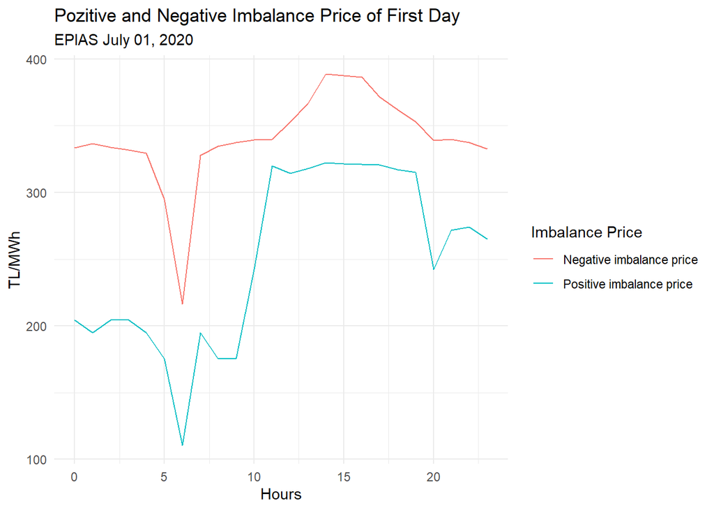

```r
raw_df %>%
  select(Date, PositiveIP, NegativeIP)%>%
  group_by(Day = lubridate::day(Date), Hour = lubridate::hour(Date))%>%
  select(Day,Hour, PositiveIP, NegativeIP)%>%
  filter(Day==1)%>%

  ggplot(aes(Hour, color = "Hours"))+
    geom_line(aes(y=PositiveIP, color = "Positive imbalance price")) +
    geom_line(aes(y=NegativeIP, color = "Negative imbalance price")) +
    labs(x = "Hours", y = "TL/MWh",
         title= "Pozitive and Negative Imbalance Price of First Day",
         subtitle = "EPIAS July 01, 2020",
         color = "Imbalance Price") +
    theme_minimal()
```

#### 3.2. Negative and positive inbalance price in last day

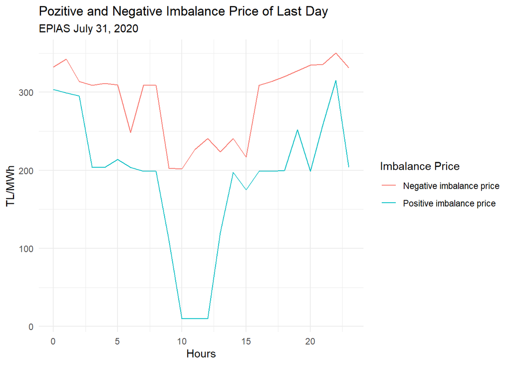

```r
raw_df %>%
  select(Date, PositiveIP, NegativeIP)%>%
  group_by(Day = lubridate::day(Date), Hour = lubridate::hour(Date))%>%
  select(Day,Hour, PositiveIP, NegativeIP)%>%
  filter(Day==31)%>%

  ggplot(aes(Hour, color = "Hours"))+
    geom_line(aes(y=PositiveIP, color = "Positive imbalance price")) +
    geom_line(aes(y=NegativeIP, color = "Negative imbalance price")) +
    labs(x = "Hours", y = "TL/MWh",
         title= "Pozitive and Negative Imbalance Price of Last Day",
         subtitle = "EPIAS July 31, 2020",
         color = "Imbalance Price") +
    theme_minimal()
```

#### 3.3. Daily difference of negative and positive inbalance price

```r
EG <- raw_df %>%
        select(Date, PositiveIP, NegativeIP)%>%
        group_by(Day = lubridate::day(Date), Hour = lubridate::hour(Date))%>%
        select(Day,Hour, PositiveIP, NegativeIP)%>%
        transmute(Day,Hour,PositiveIP, NegativeIP, difference=NegativeIP-PositiveIP)%>%
        ungroup()%>%
        arrange(desc(difference)) %>%
        print(n=10)
```

```
## # A tibble: 744 x 5
##      Day  Hour PositiveIP NegativeIP difference
##    <int> <int>      <dbl>      <dbl>      <dbl>
##  1    31    12        9.7       241.       231.
##  2    31    11        9.7       227.       217.
##  3    31    10        9.7       202.       192.
##  4     1     9      176.        338.       162.
##  5     1     8      176.        335.       159.
##  6     3    14      320.        474.       154.
##  7     3    15      321.        474.       153.
##  8     8     0      174.        322.       148.
##  9     7    23      174.        320.       146.
## 10     8     1      175.        320.       146.
## # ... with 734 more rows
```

#### 3.4. Graph of daily difference of negative and positive inbalance price

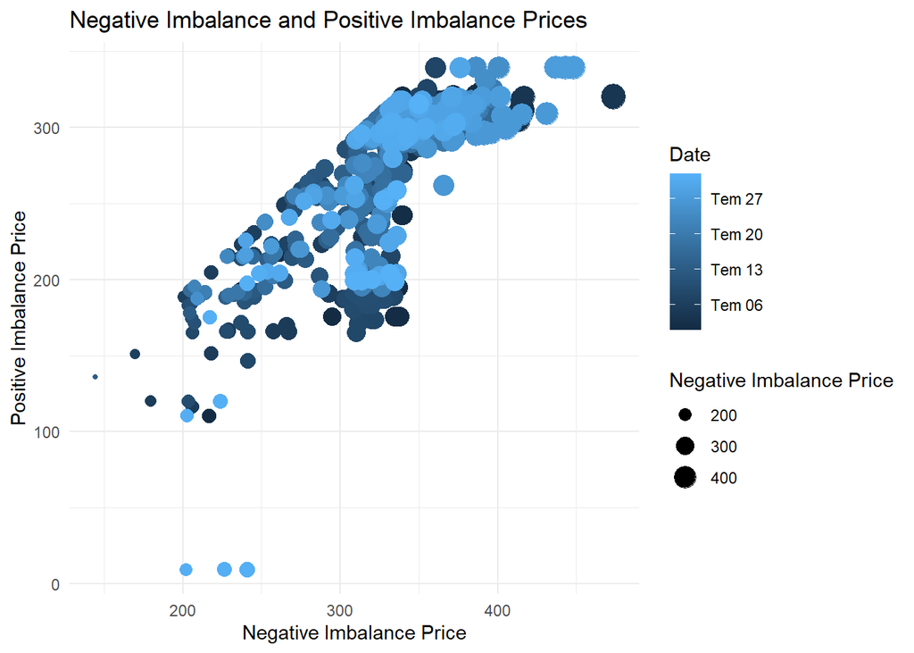

```r
raw_df%>%
    ggplot(aes(x=NegativeIP, y=PositiveIP, color=Date, size = NegativeIP)) +
      geom_point() +
      labs(x ="Negative Imbalance Price",
           y ="Positive Imbalance Price",
           title="Negative Imbalance and Positive Imbalance Prices",
           color = "Date",
           size = "Negative Imbalance Price") +
    theme_minimal()
```

Point data graph shows that, negative imbalance price and positive imbalance price concentrate in higher value.

### 4. SMP DIRECTION

Another implementation for the energy usage is about SMP direction.

#### 4.1. Pie chart of SMP direction

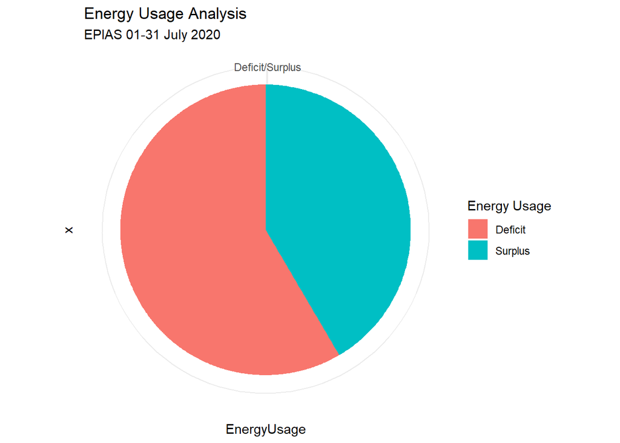

```r
raw_df %>%
  group_by(Hours = lubridate::hour(Date))%>%
  transmute(EnergyUsage = ifelse(SMPDirection == "?Energy Surplus", "Surplus", "Deficit")) %>%
  ggplot(aes(x = "", y=EnergyUsage, fill=EnergyUsage)) +
    geom_bar(stat = "identity", width = 1) +
    coord_polar("y") +
    theme_minimal() +
    labs(title = "Energy Usage Analysis",
         subtitle = "EPIAS 01-31 July 2020",
         fill = "Energy Usage")
```

Pie chart shows that, the percentage of the deficit is higher than the percentage of the surplus. That is, the energy demand is higher than the predicted energy demand.

```r
raw_df %>%
  group_by(Hours = lubridate::hour(Date))%>%
  transmute(EnergyUsage = ifelse(SMPDirection == "?Energy Surplus", "Surplus", "Deficit")) %>%
  group_by(EnergyUsage, Hours) %>%
  filter(EnergyUsage=="Deficit") %>%
  summarise(EnegyUsageNumber = n())%>%
  print(n=10)
```

```
## # A tibble: 24 x 3
## # Groups:   EnergyUsage [1]
##    EnergyUsage Hours EnegyUsageNumber
##    <chr>       <int>            <int>
##  1 Deficit         0               23
##  2 Deficit         1               23
##  3 Deficit         2               24
##  4 Deficit         3               22
##  5 Deficit         4               21
##  6 Deficit         5               21
##  7 Deficit         6               17
##  8 Deficit         7               21
##  9 Deficit         8               18
## 10 Deficit         9               22
## # ... with 14 more rows
```

Deficit value is important because when we find the deficit value, we can obtain the under predicted demand. That is, if the deficit occurs, we use more electricity than prediction.

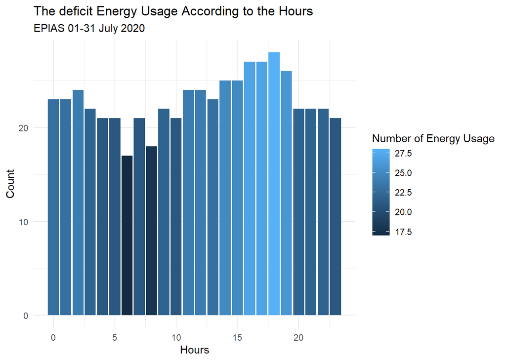

```r
raw_df %>%
  group_by(Hours = lubridate::hour(Date))%>%
  transmute(EnergyUsage = ifelse(SMPDirection == "?Energy Surplus", "Surplus", "Deficit")) %>%
  group_by(EnergyUsage, Hours) %>%
  filter(EnergyUsage=="Deficit") %>%
  summarise(EnergyUsageNumber = n())%>%

  ggplot(aes(x = Hours, y = EnergyUsageNumber, fill = EnergyUsageNumber)) +
    geom_bar(stat = "identity") +
    theme_minimal() +
    labs(title = "The deficit Energy Usage According to the Hours",
         subtitle = "EPIAS 01-31 July 2020",
         fill = "Number of Energy Usage",
         x="Hours",
         y = "Count")
```

#### 4.4. Classification of the energy surplus, energy deficit and balance

When we use the equality to calculate SMP direction, we can obtain surplus, deficit, and balance

```r
EG <- raw_df %>%
        group_by(Hour = lubridate::hour(Date))%>%
        transmute(Hour, Surplus = sum(MCP>SMP), Deficit=sum(MCP<SMP), Balance=sum(MCP==SMP))%>%
        print(n=5)
```

```
## # A tibble: 744 x 4
## # Groups:   Hour [24]
##    Hour Surplus Deficit Balance
##   <int>   <int>   <int>   <int>
## 1     0       8      21       2
## 2     1       7      22       2
## 3     2       7      22       2
## 4     3       8      18       5
## 5     4      10      17       4
## # ... with 739 more rows
```

This data shows the number of deficit, surplus, and balance according to hour in a day. To make more clear analysis for this data we can use visualization, which are given in the next section.

#### 4.5. Graph of the energy surplus, energy deficit and balance

When we use the equality to calculate SMP direction, we can obtain surplus, deficit, and balance

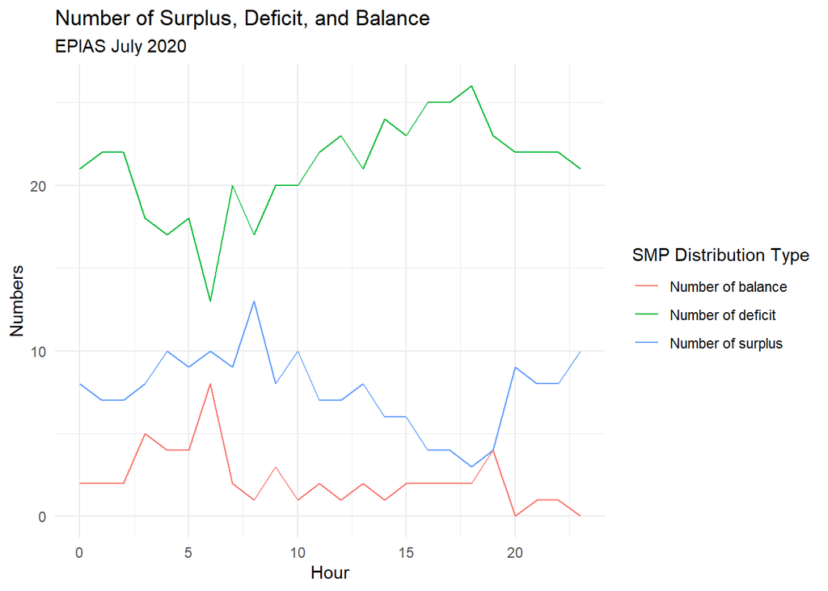

```r
raw_df %>%
  group_by(Hour = lubridate::hour(Date))%>%
  transmute(Hour, Surplus = sum(MCP>SMP), Deficit = sum(MCP<SMP), Balance = sum(MCP==SMP))%>%

  ggplot(aes(x = Hour, color = "Hours")) +
    geom_line(aes(y = Surplus, color = "Number of surplus")) +
    geom_line(aes(y = Deficit, color = "Number of deficit")) +
    geom_line(aes(y = Balance, color = "Number of balance")) +

  labs(x = "Hour",
       y = "Numbers",
       title = "Number of Surplus, Deficit, and Balance",
       subtitle = "EPIAS July 2020",
       color = "SMP Distribution Type") +
  theme_minimal()
```

This graph shows that, especially between 15 and 20 pm, the number of deficit is greater than both number of surplus and balance. The deficit means that, the energy demand is more than the predicted energy. That is, in this time interval, the more energy used than the predicted. In contrast to this information, even though there is still more deficit value according to the surplus and balance, this value is closer to surplus and balance value.However, according to the daily analysis, in each hour, we have more deficit value than surplus and balance. That is, we use more energy than predict.

This report gives some basic information about monthly energy market, i.e., MCP,SMP, positive imbalance price, negative imbalance price, and SMP direction. More information about the electricity energy market, you can visit web page of the [EPIAS](https://www.epias.com.tr/).